# Homework YY

Vaishnavi Maganti

2026-03-09

## Instructions

Answer the following questions and complete the exercises in RMarkdown. Please embed all of your code and push your final work to your repository. Your final lab report should be organized, clean, and run free from errors. Remember, you must remove the `#` for the included code chunks to run. Be sure to add your name to the author header above. For any included plots, make sure they are clearly labeled. You are free to use any plot type that you feel best communicates the results of your analysis.

Make sure to use the formatting conventions of RMarkdown to make your report neat and clean!

### Install Biostrings

```r
if (!requireNamespace("BiocManager", quietly = TRUE))
  install.packages("BiocManager")

BiocManager::install("Biostrings")
```

## Load the libraries

```r
library(tidyverse)
library(janitor)
library(dplyr)
library(readr)
library(Biostrings)
```

```r
options(scipen = 999)
```

## Background

A patient has been admitted to the hospital with a severe and rapidly progressing bacterial infection of unknown origin. Standard clinical cultures have been inconclusive. As part of the diagnostic workup, RNA was extracted directly from the patient’s tissue sample and submitted for RNA sequencing (RNA-seq). From this sequencing data, you have successfully assembled the complete coding sequence of a gene expressed by the infecting bacterium. You will use BLAST, a tool used in real clinical and research microbiology labs, to compare this unknown sequence against all known biological sequences in the NCBI database.

skip!!! **1. Read the “gene of interest” sequence from the `goi_01.txt` file into R using the Biostrings package. Store this in an object called `query_seq`.What type sequence is this? (DNA, RNA or Protien)**

```r
getwd()
```

```
## [1] "/Users/magantiv/Desktop/clone_repository_github/BIS15L_W26_vmaganti/lab16/homework"
```

**2.Perform a blastx search using `goi_01.txt` as the query and the “core_nt” database. Download the cluster table results in CSV format, change the name to “goi_01_blastx.csv” and store in the homework/data folder. Read the csv file into R and clean the column names. Save the cleaned data frame as goi_01_blastx.**

```r
goi_01_blastx <- read_csv("data/goi_01_blastx.csv") %>%
  clean_names()
goi_01_blastx
```

```
## # A tibble: 100 × 9
##    description         scientific_name max_score total_score query_cover e_value
##    <chr>               <chr>               <dbl>       <dbl> <chr>         <dbl>
##  1 MULTISPECIES: mino… Yersinia pseud…       216         263 99%         7  e-70
##  2 unknown [Yersinia … Yersinia pestis       216         216 81%         1  e-69
##  3 minor capsid prote… Yersinia pestis       215         215 81%         1  e-69
##  4 minor capsid prote… Yersinia pestis       215         215 81%         2  e-69
##  5 MULTISPECIES: mino… Enterobacter c…       215         262 99%         3  e-69
##  6 hypothetical prote… Escherichia co…       214         259 99%         1  e-68
##  7 MULTISPECIES: mino… Enterobacteria…       214         261 99%         1  e-68
##  8 minor capsid prote… Escherichia co…       213         258 99%         1  e-68
##  9 hypothetical prote… Citrobacter fr…       213         262 99%         1  e-68
## 10 minor capsid prote… Salmonella ent…       213         259 99%         1  e-68
## # ℹ 90 more rows
## # ℹ 3 more variables: per_ident <dbl>, acc_len <dbl>, accession <chr>
```

```r
names(goi_01_blastx)
```

```
## [1] "description"     "scientific_name" "max_score"       "total_score"
## [5] "query_cover"     "e_value"         "per_ident"       "acc_len"
## [9] "accession"
```

**3.Display the top 10 blastx hits, based on e_value, for this blastx search? (Include the Scientific Name, Cluster Anscestor, Cluster Representative Sequence, Max Score, Query Cover, E value and Percent Identity)**

```r
top10_blastx <- goi_01_blastx %>%
  arrange(e_value) %>%
  slice_head(n = 10) %>%
  select(scientific_name,
         description,
         accession,
         max_score,
         query_cover,
         e_value,
         per_ident)
top10_blastx
```

```
## # A tibble: 10 × 7
##    scientific_name description accession max_score query_cover e_value per_ident
##    <chr>           <chr>       <chr>         <dbl> <chr>         <dbl>     <dbl>
##  1 Yersinia pseud… MULTISPECI… "=HYPERL…       216 99%         7  e-70     100
##  2 Yersinia pestis unknown [Y… "=HYPERL…       216 81%         1  e-69     100
##  3 Yersinia pestis minor caps… "=HYPERL…       215 81%         1  e-69     100
##  4 Yersinia pestis minor caps… "=HYPERL…       215 81%         2  e-69     100
##  5 Enterobacter c… MULTISPECI… "=HYPERL…       215 99%         3  e-69      99.0
##  6 Escherichia co… hypothetic… "=HYPERL…       214 99%         1  e-68      98.1
##  7 Enterobacteria… MULTISPECI… "=HYPERL…       214 99%         1  e-68      98.1
##  8 Escherichia co… minor caps… "=HYPERL…       213 99%         1  e-68      98.1
##  9 Citrobacter fr… hypothetic… "=HYPERL…       213 99%         1  e-68      98.1
## 10 Salmonella ent… minor caps… "=HYPERL…       213 99%         1  e-68      98.1
```

**4. create a plot that shows the different in percent identity for each Scientific Name of the top 10 blastx hits. Make sure to label your axes and give your plot a title.**

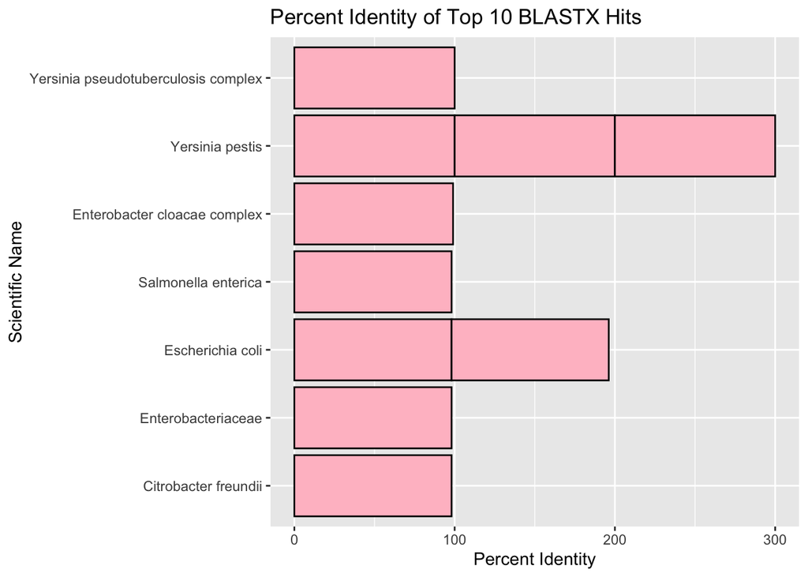

```r
top10_blastx %>%
  ggplot(aes(x = reorder(scientific_name, per_ident),
             y = per_ident)) +
  geom_col(fill = "pink", color = "black") +
  coord_flip() +
  labs(
    title = "Percent Identity of Top 10 BLASTX Hits",
    x = "Scientific Name",
    y = "Percent Identity"
  )
```

**5 Perform a blastn search using `goi_01.txt` as the query and the “core_nt” database. Download the alignment description in CSV format, change the name to “goi_01_blastn.csv” and store in the homework/data folder. Read the csv file into R and clean the column names. Save the cleaned data frame as goi_01_blastn.**

```r
goi_01_blastn <- read_csv("data/goi_01_blastn.csv") %>%
  clean_names()
goi_01_blastn
```

```
## # A tibble: 100 × 9
##    description         scientific_name max_score total_score query_cover e_value
##    <chr>               <chr>               <dbl>       <dbl> <chr>         <dbl>
##  1 Yersinia pestis st… Yersinia pestis       688         688 99%               0
##  2 Yersinia pestis st… Yersinia pestis       688         688 99%               0
##  3 Yersinia pestis st… Yersinia pestis       688         688 99%               0
##  4 Yersinia pestis st… Yersinia pestis       688         688 100%              0
##  5 Yersinia pestis st… Yersinia pestis       688         688 99%               0
##  6 Yersinia pestis st… Yersinia pestis       688         688 100%              0
##  7 Yersinia pestis st… Yersinia pestis       688         688 99%               0
##  8 Yersinia pestis st… Yersinia pestis       688         688 99%               0
##  9 Yersinia pestis st… Yersinia pestis       688         688 99%               0
## 10 Yersinia pestis CA… Yersinia pesti…       688         688 100%              0
## # ℹ 90 more rows
## # ℹ 3 more variables: per_ident <dbl>, acc_len <dbl>, accession <chr>
```

```r
names(goi_01_blastn)
```

```
## [1] "description"     "scientific_name" "max_score"       "total_score"
## [5] "query_cover"     "e_value"         "per_ident"       "acc_len"
## [9] "accession"
```

**6. What was the top blastn hit, based on e_value, for this blastn search? (Include the Cluster Ancestor, Cluster, Representative Sequence, Max Score, Query Cover, E value, Percent Identity and Accession Link)**

```r
top_blastn <- goi_01_blastn %>%
  arrange(e_value) %>%
  slice_head(n = 1) %>%
  select(description,
         scientific_name,
         accession,
         max_score,
         query_cover,
         e_value,
         per_ident)

top_blastn
```

```
## # A tibble: 1 × 7
##   description  scientific_name accession max_score query_cover e_value per_ident
##   <chr>        <chr>           <chr>         <dbl> <chr>         <dbl>     <dbl>
## 1 Yersinia pe… Yersinia pestis "=HYPERL…       688 99%               0      99.2
```

Accession Link:

```r
#https://www.ncbi.nlm.nih.gov/nuccore/AAC13173
```

**7. Based on the blastx and blastn results, what do you think this gene is and what bacteria do you think it came from?**

```
Based on the blastx and blastn results, I think the gene likely comes from Yersinia pestis. It appears to focus on a protein whcih is involved in bacterial pathogenicity.
```

**8. For the top blastn hit, click on the accession link for this bacteria and download the coding sequences as a FASTA Protein file. Read the fasta file into R using the Biostrings package and store it in an object called `goi_blastn_hit`.**

```r
goi_blastn_hit <- readAAStringSet("data/goi_blastn_hit.fasta")

goi_blastn_hit
```

```
## AAStringSet object of length 1:
##     width seq                                               names
## [1]   118 MQKAKIGTVGTDIFCHYMPANVK...YPKNEGSLIEAGIPIEFAGYLLN AAC13173.1 unknow...
```

**9. From the same organism, identify 5 other annotated genes? Do these genes suggest about the biology or virulence of this bacterium?** *Annotated genes can be found in the “CDS” section of the GenBank file. You can also find genes by going to summary page for the organism and looking at the “View annotated genes” section.*

```r
#Five other annotated genes from Yersinia pestis include:
  #1) caf1 (F1 capsular antigen)
  #2) caf1A (capsule anchoring/export protein)
  #3) caf1M (capsule chaperone)
  #4) caf1R (capsule operon regulatory protein)
  #5) ymt (murine toxin)
#These genes are associated with capsule formation and regulation which are virulence factors that contribute to the Yersinia pestis's ability to avoid the immune system and establish infection.
```

**10. Now that you have an idea of this bacteria’s identity, what illness/disease do you think the patient has? What is the historical or public health significance of this disease? Based on the gene you identified, what role might this gene play in pathogenicity?**

```
The illness and disease that the patient by possible have is a bacterial infection caused by Yersinia pestis, leading to the bubonic plague or pneumonic plague. The historical significance of this disease is the Black Death in the 14th century, which killed millions of people. This gene plays a role in zoonotic pathogenicity, where it is transmitted from rodents to humans via fleas, with some of these strains being highly virulent.
```

## Knit and Upload

Please knit your work as an .html file and upload to Canvas. Homework is due before the start of the next lab. No late work is accepted. Make sure to use the formatting conventions of RMarkdown to make your report neat and clean!